# Computational Essay

# Introduction

# Import Libraries and Data sets

We import libraries that are needed to perform data extraction and manipulation like tidycensus, sf, dplyr, tidyr. We use the Census API to fetch data from ACS using the key and store it in a sf object for further transformations. The other data sets for Airbnb, zip codes and water bodies were downloaded in the form a csv and shapefiles respectively and then used in our environment with the help of libraries we imported.

# Preparing the Data

The data we fetched from Census API has a variable ‘B01003_001’ which is basically Total Population in that census tract, we need to normalize this data set for each area by dividing it by the area of that census tract. So finally we use Population Density for our analysis instead of Total Population. The area of census tract is calculated using column ‘geometry’ in acs_data and then the total population is divided by it. We also pivot the value of our variables from rows to columns for better readability and analysis.

The data set for Airbnb was in the form of csv so it has no coordinate reference system so when we convert it into an sf object it automatically assigns EPSG:4326 which is a standard geographic CRS which is represented in latitude and longitude (commonly used for navigation purposes). Since we need to join, manipulate and model different variables from multiple data sets in our analysis we convert all data sets to one Projected CRS so that the final map is spatially aligned for different layers of data plotted. The projected coordinate reference system used in Texas is EPSG:3081 so we convert the CRS of all our data sets to 3081.

```r
# Convert the air bnb data into an sf object
airbnb_sf <- st_as_sf(airbnb_data, coords = c("longitude", "latitude"), crs = 4326)

# Transform acs data structure for population density
acs_data_sf <- st_as_sf(acs_data)

# Extract population density
acs_data_sf <- acs_data_sf %>%
  mutate(
    area_sq_km = as.numeric(st_area(geometry)) / 1e6,
    estimate_new = case_when(
      variable == "B01003_001" ~ estimate / area_sq_km,
      variable == "B19013_001" ~ estimate,
      TRUE ~ NA_real_
    )
  )

acs_data_clean <- acs_data_sf %>%
  select(GEOID, NAME, variable, estimate, estimate_new, geometry) %>%
  pivot_wider(
    names_from = variable,
    values_from = c(estimate, estimate_new),
    names_glue = "{variable}_{.value}"
  )


# Convert crs of datasets to 3081
airbnb_sf_3081 <- st_transform(airbnb_sf, crs = 3081)
zip_sf <- st_transform(zip_sf, crs = 3081)
acs_data_3081 <- st_transform(acs_data_clean, crs = 3081)
```

# Map 1

The Map derived below shows total airbnb listings per zip code along with average price of these listings per zip code. The intent behind this visualisation is to highlight zip codes in Austin which already have high number of listings and what is their average price to give a fair idea of how much it would cost a guest to get a rental property on an average and how many options would they have. From the map we see most of the listings are clustered in central region of Austin which appears to be the center of the city. The average price of these listings in the central region is also slightly on the higher side. One more interesting observation that can be made is that average price of listings is higher in the western region of Austin and lower in the eastern region of Austin. So there are higher chances of getting a cheap rental in east and more expensive rental in west of Austin along with fairly less options in both regions since most listings are centered around central region of Austin.

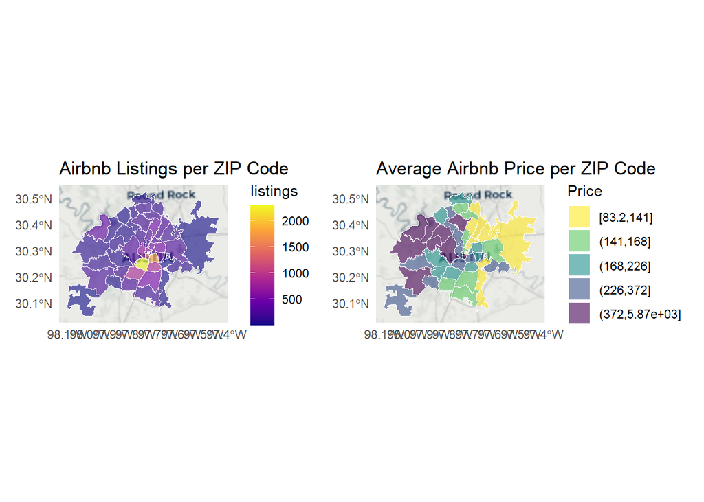

```r
# Spatial join
airbnb_zip <- st_join(airbnb_sf_3081, zip_sf, join = st_within)

# Listing count
listing_counts <- airbnb_zip %>%
  st_set_geometry(NULL) %>%
  group_by(ZCTA5CE20) %>%
  summarise(listings = n())

# Average price per ZIP
avg_price <- airbnb_zip %>%
  st_set_geometry(NULL) %>%
  group_by(ZCTA5CE20) %>%
  summarise(avg_price = mean(price, na.rm = TRUE))

# Merge counts + price back to ZIP polygons
zip_sf_stats <- zip_sf %>%
  left_join(listing_counts, by = "ZCTA5CE20") %>%
  left_join(avg_price, by = "ZCTA5CE20")

# Keep only ZIP codes with at least 1 listing
zip_sf_filtered <- zip_sf_stats %>%
  filter(listings > 0)

# Create quantile bins for visual scaling
zip_sf_filtered$price_quantile <- cut(
  zip_sf_filtered$avg_price,
  breaks = quantile(zip_sf_filtered$avg_price, probs = seq(0, 1, 0.2), na.rm = TRUE),
  include.lowest = TRUE
)

# Plot
p1 <-  ggplot(zip_sf_filtered) +
          annotation_map_tile(
            type = "cartolight",  # CartoDB Positron
            zoom = NULL           # automatic zoom
          ) +
          geom_sf(aes(fill = listings), color = "white", alpha = 0.6) +
          scale_fill_viridis_c(option = "plasma") +
          labs(title = "Airbnb Listings per ZIP Code") +
          theme_minimal()

p2 <- ggplot(zip_sf_filtered) +
  annotation_map_tile(type = "cartolight", zoom = NULL) +
  geom_sf(aes(fill = price_quantile), color = "white", alpha = 0.6) +
  scale_fill_viridis_d(option = "viridis", direction = -1) +
  labs(
    title = "Average Airbnb Price per ZIP Code",
    fill = "Price"
  ) +
  theme_minimal()

combined_map <- p1 + p2 + plot_layout(ncol = 2)

print(combined_map)
```

# Map 2

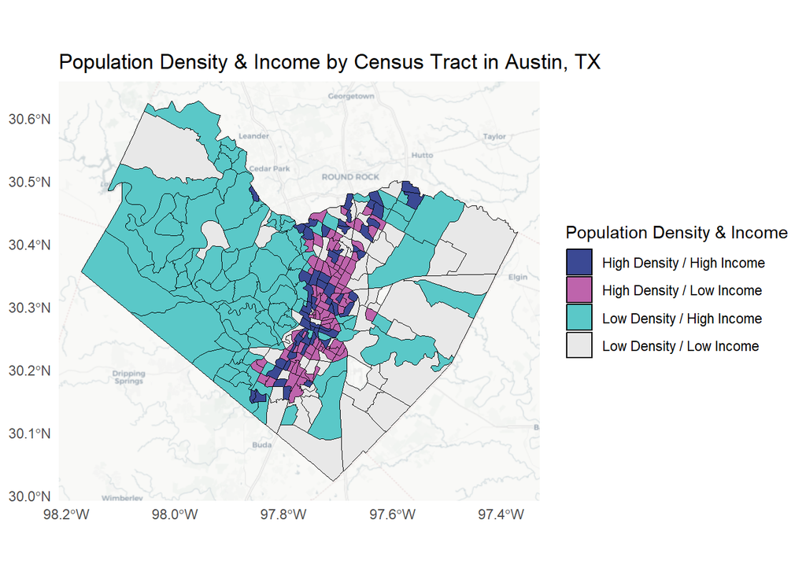

```r
# Remove NA values
acs_data_3081 <- acs_data_3081 %>%
  filter(
    !is.na(B01003_001_estimate_new),
    !is.na(B19013_001_estimate)
  )


# Quantile-based 2x2 classification
dens_quant <- quantile(acs_data_3081$B01003_001_estimate_new, probs = c(0.5), na.rm = TRUE)
income_quant <- quantile(acs_data_3081$B19013_001_estimate, probs = c(0.5), na.rm = TRUE)

acs_data_3081$dens_class2 <- ifelse(
  acs_data_3081$B01003_001_estimate_new <= dens_quant,
  "Low Density", "High Density"
)

acs_data_3081$income_class2 <- ifelse(
  acs_data_3081$B19013_001_estimate <= income_quant,
  "Low Income", "High Income"
)

acs_data_3081$bivar2 <- paste(
  acs_data_3081$dens_class2,
  acs_data_3081$income_class2,
  sep = " / "
)

# Palette
bivar2_palette <- c(
  "Low Density / Low Income"  = "#e8e8e8",
  "Low Density / High Income" = "#5ac8c8",
  "High Density / Low Income" = "#be64ac",
  "High Density / High Income"= "#3b4994"
)


# Transform ACS data to lon/lat
acs_data_4326 <- st_transform(acs_data_3081, 4326)

# Get bounding box from ACS tracts
austin_bbox <- st_bbox(acs_data_4326)

# Create the map
map2 <- ggplot() +
  ggspatial::annotation_map_tile(type = "cartolight", zoomin = 0) +
  geom_sf(data = acs_data_4326,
          aes(fill = bivar2),
          color = "black", size = 0.2) +
  scale_fill_manual(
    values = bivar2_palette,
    name = "Population Density & Income"
  ) +
  coord_sf(xlim = c(austin_bbox["xmin"], austin_bbox["xmax"]),
           ylim = c(austin_bbox["ymin"], austin_bbox["ymax"]),
           crs = 4326) +
  theme_minimal() +
  labs(title = "Population Density & Income by Census Tract in Austin, TX") +
  theme(legend.position = "right")

print(map2)
```

# Map 3

Map 3 is directed towards the view point of having an Airbnb with a good view and for this we use our data set for ocean and lakes to filter out those zip codes which would give tourist attraction. For the central region of Austin where most of the listings are clustered we can see a lake in blue which intersects the central region. After plotting log (price) for all listings we see a lot of cheap rentals are clustered on the right side whereas fewer expensive listings on the left side of the cluster which aligns with our previous map since the region on the left of central Austin is high income and on the right of central Austin is low income. One interesting avenue here is that if someone wants to invest in a property with a good view left of central Austin would be a good choice since it has fewer listings which are already quite expensive. So you could market your property with reasonable rates with less competition.

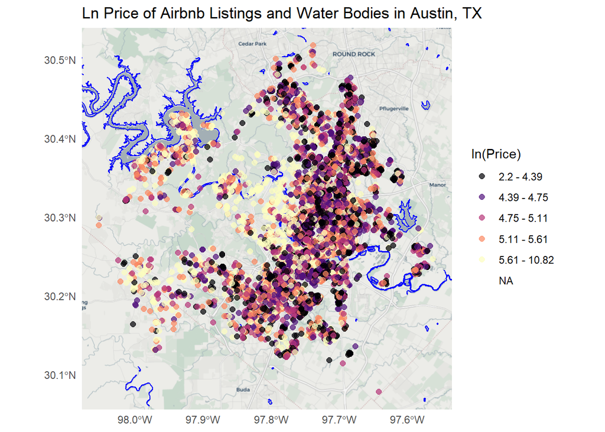

```r
water_lines_sf <- st_boundary(waterbodies_sf)

# Approx Austin bounding box in EPSG:3081
xlim_austin <- c(1165000, 1288000)  # EPSG:3081 X
ylim_austin <- c(876000, 941500)    # EPSG:3081 Y


# Compute ln(price)
airbnb_sf_3081$ln_price <- log(airbnb_sf_3081$price)

# Create 5 bins (quintiles) based on ln(price)
lnprice_bins <- classIntervals(airbnb_sf_3081$ln_price, n = 5, style = "quantile")

# Format the labels to show the range of ln(price) in each bin
bin_labels <- paste0(round(lnprice_bins$brks[-6], 2), " - ", round(lnprice_bins$brks[-1], 2))

# Assign bins
airbnb_sf_3081$lnprice_bin <- cut(airbnb_sf_3081$ln_price,
                                  breaks = lnprice_bins$brks,
                                  include.lowest = TRUE,
                                  labels = bin_labels)


airbnb_sf_4326      <- st_transform(airbnb_sf_3081, 4326)
waterbodies_4326    <- st_transform(waterbodies_sf, 4326)
water_lines_4326    <- st_boundary(waterbodies_4326)

# Bbox in lon/lat from Airbnb points
austin_bbox <- st_bbox(airbnb_sf_4326)

# Assign the plot to a variable
map3 <- ggplot() +
  ggspatial::annotation_map_tile(type = "cartolight", zoomin = 0) +
  geom_sf(data = water_lines_4326, color = "blue", size = 0.5) +
  geom_sf(data = airbnb_sf_4326,
          aes(color = lnprice_bin),
          alpha = 0.7, size = 2) +
  scale_color_viridis(discrete = TRUE, name = "ln(Price)", option = "magma") +
  coord_sf(xlim = c(austin_bbox["xmin"], austin_bbox["xmax"]),
           ylim = c(austin_bbox["ymin"], austin_bbox["ymax"]),
           crs = 4326) +
  theme_minimal() +
  labs(title = "Ln Price of Airbnb Listings and Water Bodies in Austin, TX") +
  theme(legend.position = "right")

print(map3)
```

# Map 4

This Map is created to show degree of spatial auto correlation for Airbnb listings. We use LISA clusters to show areas of high-high listing clusters in red, low-low clusters in blue along with high-low and low-high for spatial outliers. Global Moran’s I = 0.55 shows strong positive spatial correlation, meaning tracts with high listing counts tend to be near other high-listing tracts, and low-listing tracts near other low-listing areas. LISA clusters further highlights areas of hot spots and cold spots for Airbnb. This map would help investors to decide if they want to put their money in higher competition (hotspots, high-high) clusters or low competition (coldspots, low-low) clusters.

```r
# Spatial join between point data and polygon data
joined_sf <- st_join(airbnb_sf_3081, acs_data_3081, join = st_within)

# Air bnb listing per census tract
airbnb_counts <- joined_sf %>%
  group_by(GEOID) %>%
  summarise(listing_count = n())

airbnb_counts_df <- airbnb_counts %>%
  st_drop_geometry()

# Merge back listing count to acs data
acs_with_airbnb <- acs_data_3081 %>%
  left_join(airbnb_counts_df, by = "GEOID") %>%
  mutate(listing_count = ifelse(is.na(listing_count), 0, listing_count))


# Population density
pop_density <- acs_with_airbnb$B01003_001_estimate_new

# Use quantile breaks (quartiles)
breaks <- classIntervals(pop_density, n = 5, style = "quantile")$brks

# Create labels for legend
labels <- paste0(round(breaks[-length(breaks)]), " - ", round(breaks[-1]))

# Cut population density into classes using the labels
acs_with_airbnb$pop_class_label <- cut(
  acs_with_airbnb$B01003_001_estimate_new,
  breaks = breaks,
  include.lowest = TRUE,
  labels = labels
)


# Define bounding box for Austin
austin_bbox_sf <- st_as_sfc(st_bbox(c(xmin = 1164619.8559, ymin = 876161.2759,
                                      xmax = 1288279.3488, ymax = 941374.4760),
                                    crs = st_crs(3081)))


# Get the bbox
bbox <- st_bbox(austin_bbox_sf)


# Convert sf to sp
nb <- poly2nb(acs_with_airbnb)  # neighbours based on shared borders (Queen contiguity)
lw <- nb2listw(nb, style = "W", zero.policy = TRUE)  # row-standardized weights

# Standardize listings
listing_std <- as.numeric(scale(acs_with_airbnb$listing_count))

# Moran's I
global_moran <- moran.test(listing_std, lw, zero.policy = TRUE)
global_moran
```

```
    Moran I test under randomisation

data:  listing_std
weights: lw

Moran I statistic standard deviate = 16.931, p-value < 2.2e-16
alternative hypothesis: greater
sample estimates:
Moran I statistic       Expectation          Variance
      0.552330861      -0.003508772       0.001077784
```

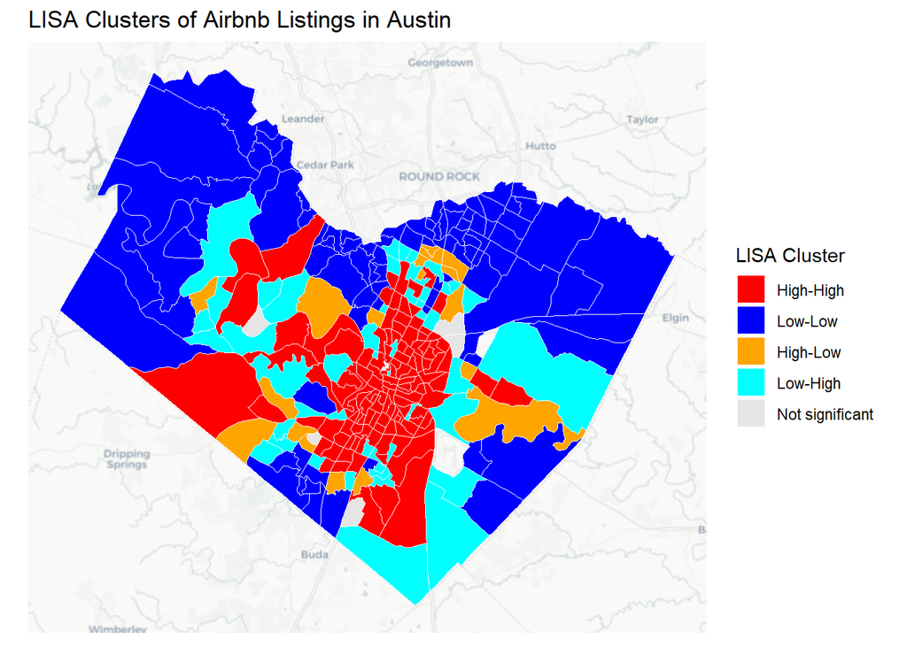

```r
# Moran Scatter Plot
# Calculate spatial lag of standardized listings
lag_listing <- lag.listw(lw, listing_std, zero.policy = TRUE)

moran_df <- data.frame(listing_std = listing_std, lag_listing = lag_listing)

# Moran Scatterplot
moran_fig <- ggplot(moran_df, aes(x = listing_std, y = lag_listing)) +
  geom_point(color = "blue", alpha = 0.5) +
  geom_smooth(method = "lm", se = FALSE, color = "red") +
  labs(title = "Moran Scatterplot (Standardized Airbnb Listings)",
       x = "Standardized Listings",
       y = "Spatial Lag of Listings") +
  theme_minimal()

local_moran <- localmoran(listing_std, lw, zero.policy = TRUE)

# Attach results back to sf
acs_with_airbnb$Ii <- local_moran[,1]      # local Moran I statistic
acs_with_airbnb$Ii_p <- local_moran[,5]    # p-value

# Define p-value threshold for significance
p_threshold <- 0.1

# Assign LISA quadrants using median split
median_std <- median(listing_std)

acs_with_airbnb$cluster <- NA
acs_with_airbnb$cluster[listing_std > median_std & lag_listing > median_std] <- "High-High"
acs_with_airbnb$cluster[listing_std < median_std & lag_listing < median_std] <- "Low-Low"
acs_with_airbnb$cluster[listing_std > median_std & lag_listing < median_std] <- "High-Low"
acs_with_airbnb$cluster[listing_std < median_std & lag_listing > median_std] <- "Low-High"


# Convert to factor for consistent ordering
acs_with_airbnb$cluster <- factor(acs_with_airbnb$cluster,
                                  levels = c("High-High","Low-Low","High-Low","Low-High"))

# Create a visualization column including non-significant tracts
acs_with_airbnb$cluster_vis <- as.character(acs_with_airbnb$cluster)
acs_with_airbnb$cluster_vis[is.na(acs_with_airbnb$cluster_vis)] <- "Not significant"
acs_with_airbnb$cluster_vis <- factor(acs_with_airbnb$cluster_vis,
                                      levels = c("High-High","Low-Low","High-Low","Low-High","Not significant"))

# Transform ACS polygons to lon/lat
acs_with_airbnb_4326 <- st_transform(acs_with_airbnb, 4326)

# Get bounding box for the plot
lisa_bbox <- st_bbox(acs_with_airbnb_4326)

# Plot LISA clusters
lisa <- ggplot() +
  ggspatial::annotation_map_tile(type = "cartolight", zoomin = 0) +
  geom_sf(data = acs_with_airbnb_4326, aes(fill = cluster_vis), color = "white", size = 0.2) +
  scale_fill_manual(
    values = c("High-High" = "red",
               "Low-Low" = "blue",
               "High-Low" = "orange",
               "Low-High" = "cyan",
               "Not significant" = "grey90"),
    name = "LISA Cluster"
  ) +
  coord_sf(xlim = c(lisa_bbox["xmin"], lisa_bbox["xmax"]),
           ylim = c(lisa_bbox["ymin"], lisa_bbox["ymax"]),
           crs = 4326) +
  labs(title = "LISA Clusters of Airbnb Listings in Austin") +
  theme_minimal() +
  theme(
    legend.position = "right",
    axis.text = element_blank(),
    axis.ticks = element_blank()
  )

# Print
print(lisa)
```

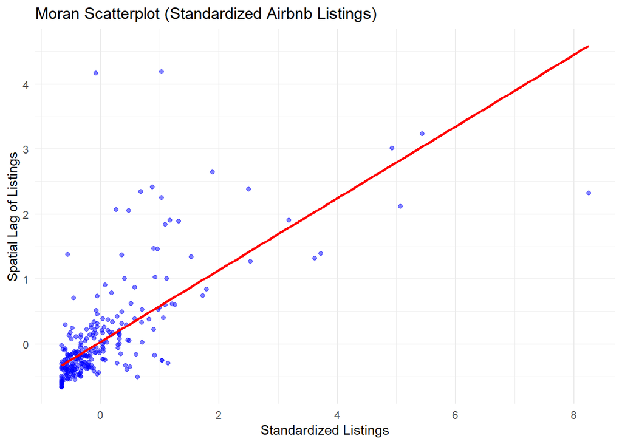

```r
print(moran_fig)
```

# Map 5

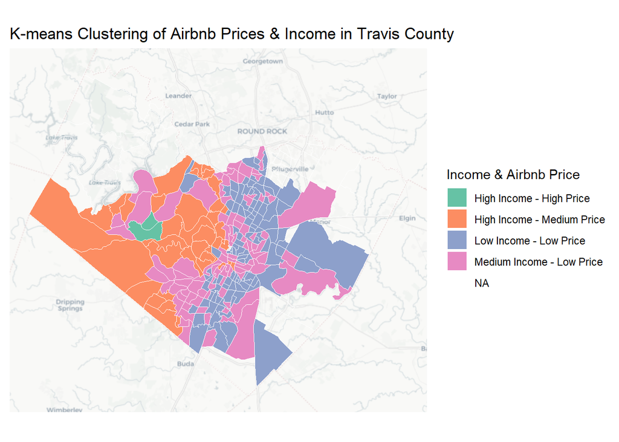

```r
# Spatial join between point data and polygon data
joined_sf <- st_join(airbnb_sf_3081, acs_data_3081, join = st_within)

# Aggregate Airbnb prices by census tract
tract_data <- joined_sf %>%
  st_set_geometry(NULL) %>%
  group_by(GEOID, B19013_001_estimate_new) %>%  # Median income per tract
  summarise(avg_price = mean(price, na.rm = TRUE)) %>%
  ungroup()


# Normalise median income and average price
tract_data_scaled <- tract_data %>%
  mutate(
    median_income_scaled = scale(B19013_001_estimate_new),
    avg_price_scaled = scale(avg_price)
  )

# Remove rows with NA or infinite values
tract_data_scaled_clean <- tract_data_scaled %>%
  filter(!is.na(median_income_scaled),
         !is.na(avg_price_scaled),
         !is.infinite(median_income_scaled),
         !is.infinite(avg_price_scaled))

tract_data_scaled_clean <- tract_data_scaled_clean %>%
  mutate(
    log_income = log1p(B19013_001_estimate_new),
    log_price  = log1p(avg_price),
    log_income_scaled = scale(log_income),
    log_price_scaled  = scale(log_price)
  )

set.seed(123)
kmeans_result <- kmeans(tract_data_scaled_clean[, c("median_income_scaled", "avg_price_scaled")], centers = 4)

# Add cluster assignment
tract_data_scaled_clean$cluster <- as.factor(kmeans_result$cluster)


acs_clusters_sf <- acs_data_3081 %>%
  left_join(tract_data_scaled_clean %>% select(GEOID, cluster), by = "GEOID")

cluster_labels <- c(
  "1" = "High Income - Medium Price",
  "2" = "Medium Income - Low Price",
  "3" = "High Income - High Price",
  "4" = "Low Income - Low Price"
)

# Add to spatial object
acs_clusters_sf$cluster_label <- cluster_labels[acs_clusters_sf$cluster]

# Transform clusters to lon/lat for basemap
acs_clusters_4326 <- st_transform(acs_clusters_sf, 4326)

# Get bounding box for the plot
clusters_bbox <- st_bbox(acs_clusters_4326)

# Plot
map5 <- ggplot() +
  ggspatial::annotation_map_tile(type = "cartolight", zoomin = 0) +
  geom_sf(data = acs_clusters_4326,
          aes(fill = cluster_label),
          color = "white", size = 0.2) +
  scale_fill_brewer(palette = "Set2", name = "Income & Airbnb Price") +
  coord_sf(xlim = c(clusters_bbox["xmin"], clusters_bbox["xmax"]),
           ylim = c(clusters_bbox["ymin"], clusters_bbox["ymax"]),
           crs = 4326) +
  labs(title = "K-means Clustering of Airbnb Prices & Income in Travis County") +
  theme_minimal() +
  theme(
    legend.position = "right",
    axis.text = element_blank(),
    axis.ticks = element_blank()
  )

print(map5)
```

# Conclusion

From the above map we see that there is a small region in west of Austin which is green and signifies high income - high price, this region also has fewer listings as derived from previous maps and low population density which creates an opportunity for investors and decision makers to invest there since the region signifies strong purchasing power along with low price sensitivity. It could be a good decision to acquire or lease luxury property in that area along with premium services which could target rich people. The property would be a tourist attraction also because of the lake view that crosses that region.